# Climate Change and Hurricanes

Amy Herring

2022-07-07

## Introduction

Climate modelers predict that global warming will cause hurricanes with more intense rainfall and increased risk of coastal flooding due to higher levels of storm surge driven by rising sea levels as a consequence of climate change. Thus whether or not the frequency of hurricanes incrases, they predict the consequences of each hurricane may be more dire.

```r
library(tidyverse)
```

## Read and process data

```r
library(readxl)
hurricane <- read_excel("data/atlantic_hurricanes_1851_2021.xlsx",sheet=1)

glimpse(hurricane)
```

```
## Rows: 171
## Columns: 8
## $ Year                         <dbl> 1851, 1852, 1853, 1854, 1855, 1856, 1857,…
## $ `Named Storms`               <dbl> 6, 5, 8, 5, 5, 6, 4, 6, 8, 7, 8, 6, 9, 5,…
## $ `Named Storm Days`           <dbl> 23.75, 33.25, 25.00, 14.50, 8.50, 23.50, …
## $ Hurricanes                   <dbl> 3, 5, 4, 3, 4, 4, 3, 6, 7, 6, 6, 3, 5, 3,…
## $ `Hurricane Days`             <dbl> 7.50, 23.50, 20.50, 7.25, 4.00, 12.75, 15…
## $ `Major Hurricanes`           <dbl> 1, 1, 2, 1, 1, 2, 0, 0, 1, 1, 0, 0, 0, 0,…
## $ `Major Hurricane Days`       <dbl> 1.00, 2.50, 9.25, 2.00, 1.00, 2.50, 0.00,…
## $ `Accumulated Cyclone Energy` <dbl> 36.2, 73.3, 76.5, 31.0, 18.1, 48.9, 46.8,…
```

Later in the course, we’ll learn how to wrangle data in a variety of different formats. The current data is organized with one row per year, and different columns for different types of storms. Our plot will be a bit easier if we rearrange the data into “long” format.

```r
stormplot <- hurricane %>%
  select(!c('Named Storm Days','Hurricane Days','Major Hurricane Days','Accumulated Cyclone Energy')) %>%
  pivot_longer(
    cols = c('Named Storms','Hurricanes','Major Hurricanes'),  # variables containing counts of named storms, named hurricanes, and named major hurricanes
    names_to = "Type",  # column names -> new column called Storm Type
    values_to = "Count"     # values in columns -> new column called Count
    )

glimpse(stormplot)
```

```
## Rows: 513
## Columns: 3
## $ Year  <dbl> 1851, 1851, 1851, 1852, 1852, 1852, 1853, 1853, 1853, 1854, 1854…
## $ Type  <chr> "Named Storms", "Hurricanes", "Major Hurricanes", "Named Storms"…
## $ Count <dbl> 6, 3, 1, 5, 5, 1, 8, 4, 2, 5, 3, 1, 5, 4, 1, 6, 4, 2, 4, 3, 0, 6…
```

## Visualization

The following visualization shows count of storms of each type by year. Note that the counts should not be added together within a year: major hurricanes started off as named storms and progressed to hurricanes and then major hurricanes with increasing wind speed.

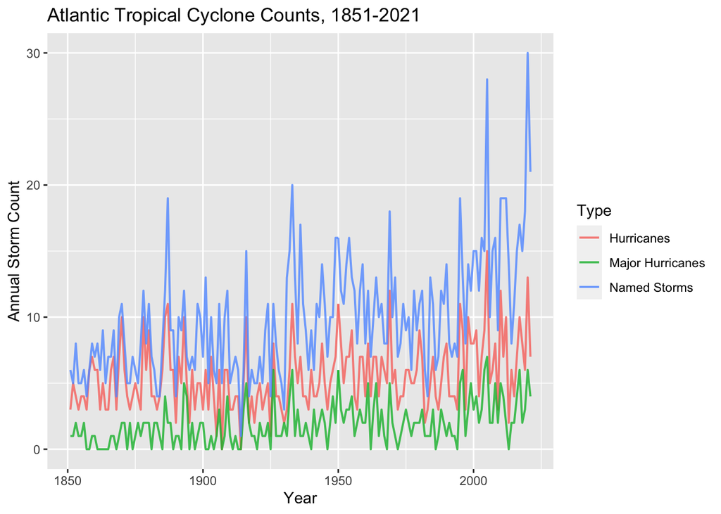

```r
ggplot(data = stormplot,
       mapping = aes(x = Year,
                     y = Count,
                     color = Type)) +
  # represent cumulative cases with lines
  geom_line(size = 0.7, alpha = 0.8) +
  # customize labels
  labs(
    y = "Annual Storm Count",
    title = "Atlantic Tropical Cyclone Counts, 1851-2021"
  )
```

Feel free to modify the code as you wish – it might be useful to limit to more recent years to examine recent trends.

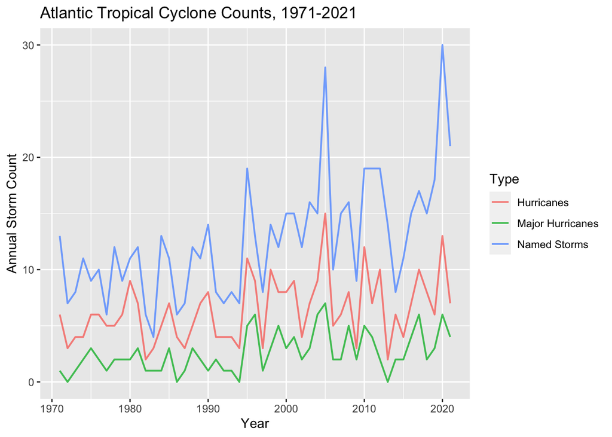

```r
stormrecent <- stormplot %>%
  filter(Year>1970)

ggplot(data = stormrecent,
       mapping = aes(x = Year,
                     y = Count,
                     color = Type)) +
  # represent cumulative cases with lines
  geom_line(size = 0.7, alpha = 0.8) +
  # customize labels
  labs(
    y = "Annual Storm Count",
    title = "Atlantic Tropical Cyclone Counts, 1971-2021"
  )
```